# mmWave Diagnostic Monitoring User Guide

# Overview

This demo is a reference application to showcase the usage of mmWave Sensor’s inbuilt Diagnostic & Monitoring feature using mmWave SafeTI Diagnostic Library (SDL) and RadarSS respectively. This demo assists in the development of software applications involving functional safety. Here is the list of features this demo provides-

- Demonstrating easy implementation of safety & monitoring functionality in mmWave Radar Sensors
- Demonstrating System level safety feature
- Make use of safety features to build ASIL-B/SIL2 mmWave sensor
- Secondary Bootloader (SBL) runs few of destructive diagnostic tests.
- After diagnostic test execution, SBL boots the main application.
- Main application executes remaining diagnostic test and device monitor features.
- TI-RTOS based MSS implementation of diagnostic tests.
- Non-OS (bare metal) based DSS implementation of diagnostic tests.
- All the test status is reported over UART.
- MSS runs periodic diagnostic tests post frame trigger.

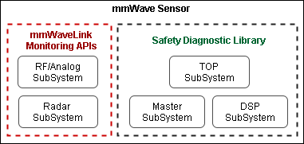

# Expectation of Lab

| IS | IS NOT |
| --- | --- |
| Reference design using mmWave Radar and PMIC | ASIL-B/D Safety design |
| Reference example to demonstrate the safety features mentioned in Safety manual | Safety Software deliverable |
| Tool to estimate monitoring threshold | Monitoring recommendation |
| Based on TIRTOS and provides OSAL for Safety OS integration | Safety OS |

# Quickstart

## 1. Hardware and Software Requirements

### Hardware

[output not shown]

### Software

| Tool | Version | Required For | Download Link |
| --- | --- | --- | --- |
| Uniflash | Latest | Quickstart Firmware | [Download offline tool](http://www.ti.com/tool/UNIFLASH) or use [cloud version](https://dev.ti.com/uniflash/#!/) |

## 2. Flash the EVM

This reference TI design contain SBL as well as Main application, ideal way to flash the SBL image first which will load & execute main application.

Flash the SBL binary (_diag_sbl*.bin) associated with the EVM platform listed below using UniFlash. Follow the instructions for using UniFlash.

However, user can flash the main application binary file (_diag_mon_demo.bin) as well without SBL loader. Main application doesn’t have any dependency on SBL. Instruction to flash and execute this would be similar to SBL.

| Plateform | Binary Name | Location |
| --- | --- | --- |
| AWR18xx | xwr18xx_diag_sbl.bin xwr18xx_diag_mon_demo.bin | `diagnostic_monitor_ref\ti\demo\diag_mon_ref\prebuilt_binaries` `diagnostic_monitor_ref\utils\diag_sbl\prebuilt_binaries` |
| xWR68xx | xwr68xx_diag_sbl.bin xwr68xx_diag_mon_demo.bin | `diagnostic_monitor_ref\ti\demo\diag_mon_ref\prebuilt_binaries` `diagnostic_monitor_ref\utils\diag_sbl\prebuilt_binaries` |

1. Load the SBL image and a factory default backup image as shown below. Factory/backup image can be any application MetaImage binary file which will get loaded in case SBL doesn’t find user application image from sFlash location or get over UART from the user.

[figure not shown]

1. Find the COM port which shows as “XDS110 Class Application/User UART” under device manager. That COM no. needs to be set in ‘Setting & Utilities’ option of UniFlash.  
   **Note**: Same xwr68xx_diag_sbl.bin & xwr68xx_diag_mon.bin binary files for both of IWR6843 and AWR6843 devices.
- Follow the instructions for Hardware Setup of ICB for Flashing Mode
- Follow the instruction to Flash the mmWave Device
1. Setup the EVM for Functional Mode
- For xWR6843ISK in Standalone/Modular Mode: Follow the instructions for Hardware Setup of AWR/IWR6843ISK for Functional Mode
- For xWR1843: Follow the instructions for Hardware Setup of IWRXXXXBOOST for Functional Mode
- For MMWAVEICBOOST + Antenna Module setup: Follow the instructions for Hardware Setup of MMWAVEICBOOST + Antenna Module for Functional Mode

At this point, the EVM should be powered, connected to the PC, flashed with the demo, and put in functional mode. The hardware setup is now complete.

## 4. Run the Lab

By this time SBL metaImage is already flashed to the EVM. As this SBL is extension of original SBL which is available in mmWave SDK, so you can refer `<mmWave_SDK>\packages\ti\utils\sbl\docs\SBL_design.pdf` for detailed steps.

Important steps provided here to load the main application image.

1. Connect to the COM port found in previous step (using any serial terminal application like Teraterm, Hyperterminal etc.) and configure the port (@baudrate 115200).
2. On bootup, SBL performs PBIST and STC diagnostic test on MSS and DSS core, then proceed for main application load. It will print the following message prompting the user to press CR or SPACE to stop the autoboot process and load a new application meta image over UART.

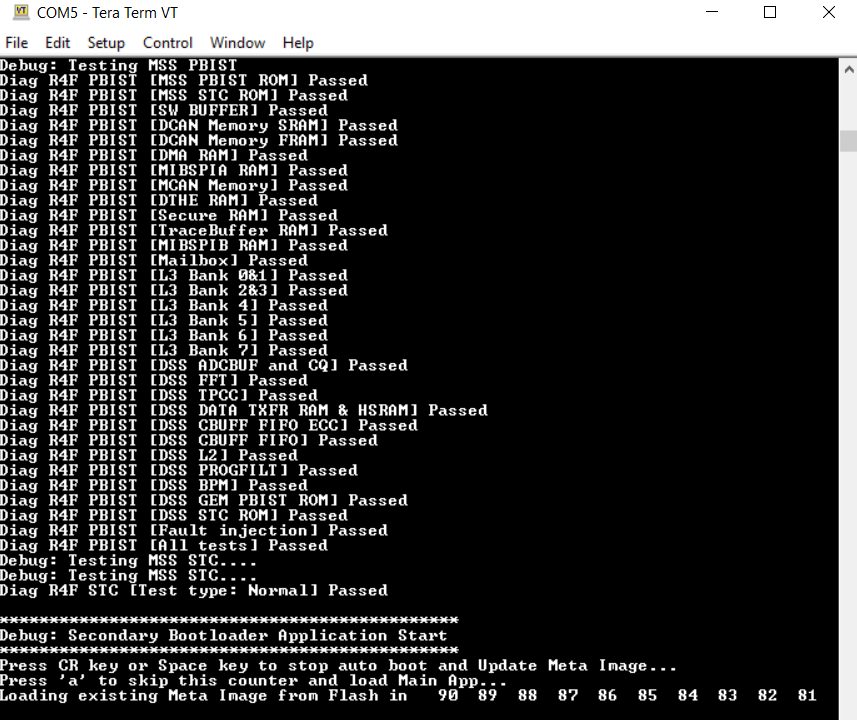

1. Press space key to stop the autoboot process. You will see the following prints. The flash at SBL_METAIMAGE_OFFSET address will be erased. Then at print of ‘CC…’ user needs to load metaImage binary via XMODEM.

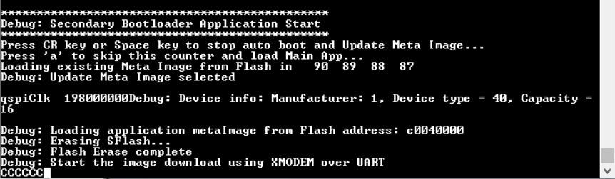

1. Start the file download using XMODEM via the Teraterm. If image load is not done in the given time frame (when ‘C’ is being written to the terminal), then SBL will timed out and re-start the loading process.

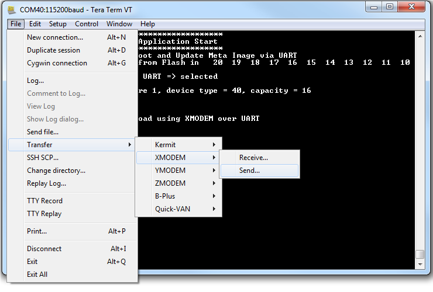

[figure not shown]

1. Once the image is downloaded, SBL verifies the image and loads from SFLASH to RAM.  
   **NOTE**: If the application meta image boot fails for any reason, the backup image is loaded from SFLASH to RAM. If both the images fail to load, SBL resets the board and goes back to original step.

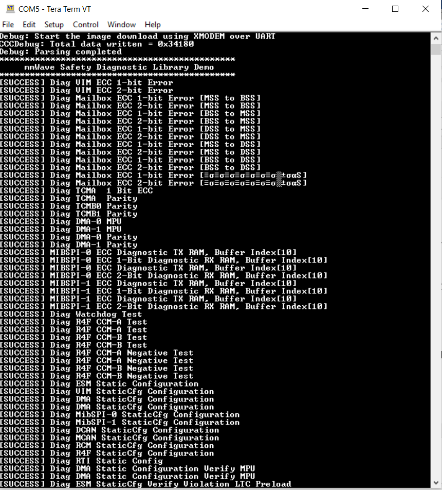

1. If main application is flashed already then user can hit ‘a’ to skip the autoboot counter and SBL will load that from sFlash and it will be executed.
2. Main application will run the miscellaneous Diagnostic test (MSS/DSS) and enable the monitoring feature of the device. On the serial terminal screen, you would see status of those tests.

[figure not shown]

1. After MSS and DSS boot time Diagnostic Injection test, MSS configures device for misc monitor features and print its failure state if any.
2. At every FTTI interval it checks for any failure monitoring report, executes set of static diagnostic test and prints the status over UART.  
   **Note**: As SBL and Main application do many of diagnostic tests which will cause nError LED (of EVM) to glow.

# Developer’s Guide

## Build the Firmware from Source Code

### 1. Software Requirements

| Tool | Version | Download Link |
| --- | --- | --- |
| TI mmWave SDK | 3.5.x | [TI mmWave SDK](http://software-dl.ti.com/ra-processors/esd/MMWAVE-SDK/latest/index_FDS.html) and all the related tools are required to be installed as specified in the mmWave SDK release notes |
| TI mmWave SDL | 1.0.x | For access to SDL please contact your local TI sales representative to get a Safety NDA signed with TI. |
| Code Composer Studio | 9.x | [Code Composer Studio v9](https://software-dl.ti.com/ccs/esd/documents/ccs_downloads.html#code-composer-studio-version-9-downloads) |
| TI SYS/BIOS | 6.73.01.01 | Included in mmWave SDK installer |
| TI ARM Compiler | 16.9.6.LTS | Included in mmWave SDK installer |
| TI CGT Compiler | 16.9.6 | Included in CCS installer |
| XDC | 3.61.3.29 | Included in mmWave SDK installer |
| mmWave Radar Device Support Package | 1.6.1 or later | Upgrade to the latest using CCS update process (see SDK user guide for more details) |
| TI Emulators Package | 7.0.188.0 or later | Upgrade to the latest using CCS update process (see SDK user guide for more details) |
| Uniflash | Latest | Uniflash tool is used for flashing TI mmWave Radar devices. [Download offline tool](http://www.ti.com/tool/UNIFLASH) or use the [Cloud version](https://dev.ti.com/uniflash/#!/) |

It’s highly recommended to refer following document from SDL installation to get acquainted with SDL design and architectures.

| Document | Details |
| --- | --- |
| /csp/mmwave_sdl_user_guide.pdf | Information on the software, installation, how to build, and other relevant information |
| /csp/API_doc/mmwave_sdl_api.pdf | API, module, data structure information generated by doxygen. HTML version at ti/docs/doxygen/html/index.html |
| /csp/Architecture_Design_Integration/mmwave_sdl_architecture.pdf | Architecture doc. HTML version at `<SDL_install_path>ti/docs/doxygen/html/index.html` |
| /csp/Architecture_Design_Integration/mmwave_sdl_design_integration.pdf | Design and Integration doc. HTML version at `<SDL_install_path>ti/docs/doxygen/html/index.html` |

### 2. Directory Structure

Package contains the SBL, OSAL and main application source codes.

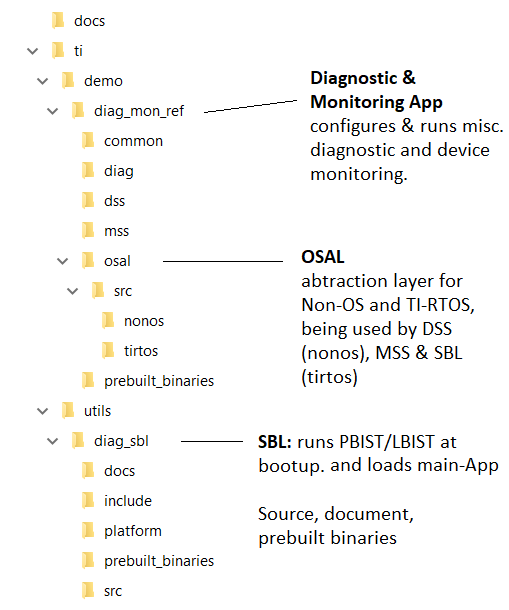

### 3. Import Lab Project

This lab contains two seperate type of projects, SBL and diagnotic & monitor Demo. Make sure that you have installed mmWave SDL (Safety Diagnostic Library), mmWave SDK and all other dependencies come along with SDK installation.  
**Note**: SDL installation doesn’t contain any library files by default, so user needs to build those. Refer build instructions from mmwave_sdl_user_guide.pdf.

> 📝 *Project Workspace*  
> When importing projects to a workspace, a copy is created in the workspace. All modifications will only be implemented for the workspace copy. The original project downloaded from the Toolbox is not touched.
1. Start CCS and setup workspace as desired.
2. Import the project(s) specified below to CCS. See instructions for importing here.
   - **diag_mon_ref_dss**
   - **diag_mon_ref_mss**
   - **mmwave_diag_sbl**

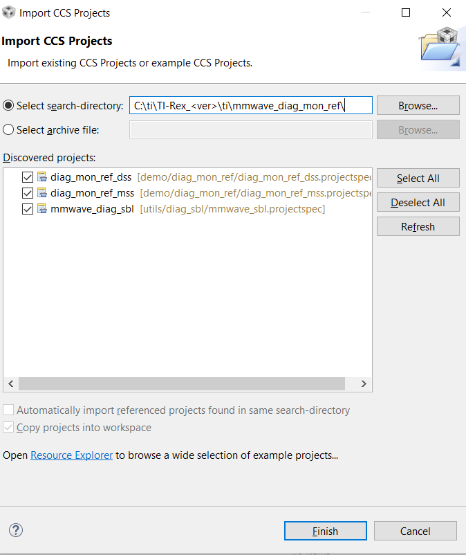

1. Verify that the import occurred without error: in CCS Project Explorer, both **diag_mon_ref_dss**, **diag_mon_ref_mss** and **mmwave_diag_sbl**should appear.
2. To execute MSS/DSS diagnostic test, application uses SDL libraries. So after projects are imported, set mmWave SDL installation path, by default that path is set to “C:/ti/mmwave_sdl_01_00_00_10” in CCS project properties.

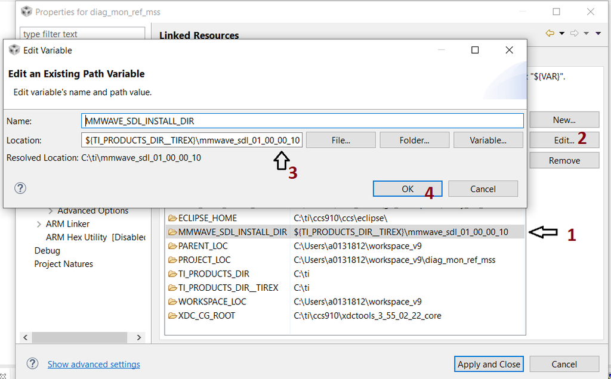

1. Same Projectspec contains CCS project for both of device variants (18xx/68xx), user can change that from CCS project properties for SBL as well as Main-application.

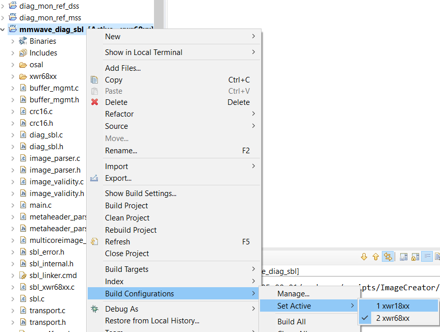

### 3. Build the Lab

SDL installation contains source files for all the DIAG, CSL components but not libraries. So user needs to build SDL libraries first for specific device variants (AWR1843/xWR6843), please refer SDL user guide for compilation instructions.

Build application DSS before application MSS, MSS project generates final MetaImage combining RadarSS, DSS and MSS images together. SBL project does not dependent on application projects.

The DSS project must be built before the MSS project.

1. Select the **diag_mon_ref_dss** so it is highlighted. Right click on the project and select **Rebuild Project**. The DSS project will build.
2. Select the **diag_mon_ref_mss** so it is highlighted. Right click on the project and select **Rebuild Project**. The MSS project will build, the the lab binary will be constructed automatically.
3. On successful build, the following should appear:
- In diag_mon_ref_dss → xwr18xx/xwr68xx, **xwr18xx_diag_mon_demo_dss.xe674/xwr68xx_diag_mon_demo_dss.xe674** (this is the C67x binary used for CCS debug mode)
  - In diag_mon_ref_mss → xwr18xx/xwr68xx, **xwr18xx_diag_mon_demo_mss.xer4f/xwr18xx_diag_mon_demo_mss.xer4f** (this is the Cortex R4F binary used for CCS debug mode) and **xwr18xx_diag_mon_demo.bin/xwr68xx_diag_mon_demo.bin** (this is the flashable binary used for deployment mode)
1. Same way rebuild mmwave_diag_sbl project → xwr18xx/xwr68xx, **xwr18xx_diag_sbl_mss.xer4f/xwr68xx_diag_sbl_mss.xer4f** (this is the Cortex R4F binary used for CCS debug mode) and **xwr18xx_diag_sbl.bin/xwr68xx_diag_sbl.bin** (this is the flashable binary used for deployment mode)

> Selecting Rebuild instead of Build ensures that the project is always re-compiled. This is especially important in case the previous build failed with errors.

> ⚠️ *Build Fails with Errors*  
> If the build fails with errors, please ensure that all the software requirements are installed as listed above and in the mmWave SDK release notes.

> 📝 *NOTE*  
> As mentioned in the Quickstart section, pre-built binary files, both debug and deployment binaries are provided in the pre-compiled directory of the lab.

### 4. Execute the Lab

There are two ways to execute the compiled code on the EVM:

- Deployment mode: the EVM boots autonomously from flash and starts running the bin image
  - Using Uniflash, for xWR6843 device flash the **xwr68xx_diag_sbl.bin** found at `<PROJECT_WORKSPACE_DIR>\mmwave_diag_sbl\xwr68xx\xwr68xx_diag_sbl.bin`
  - Using Uniflash, for xWR1843 device flash the **xwr18xx_diag_sbl.bin** found at `<PROJECT_WORKSPACE_DIR>\mmwave_diag_sbl\xwr18xx\xwr68xx_diag_sbl.bin`
  - The same procedure for flashing can be use as detailed in the Quickstart Flash the Device section.
- Debug mode: Follow the instructions for Using CCS Debug for Development

After executing the lab using either method, the lab can be executed using the Run the Lab.

## Application Overview

This application contains two set of MetaImage binaries to run, first SBL (ti\utils\diag_sbl) and second diagnostic & Monitor reference app (ti\demo\diag_mon_ref). Following figure shows the high level of flow diagram of application

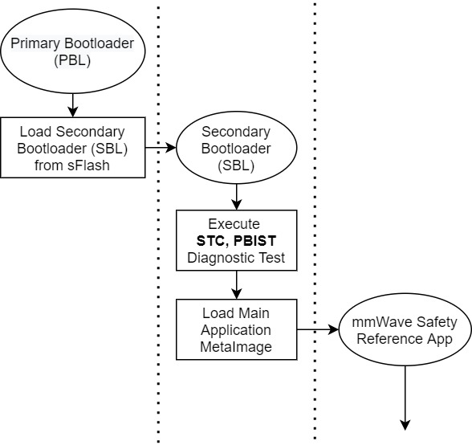

### Secondary Bootloader (SBL)

The secondary bootloader primarily is responsible for updating the application meta image in the SFLASH by receiving the image over a serial interface. It then loads and runs the updated application meta image. The ROM(primary) bootloader always loads the SBL. Application can choose to either update or load and run the application meta image. For safety applications, the SBL may be used to perform some of destructive tests like PBIST and STC that needs to be run during boot time. These tests are validated before loading the main application. In-case of failure the SBL aborts and exit.

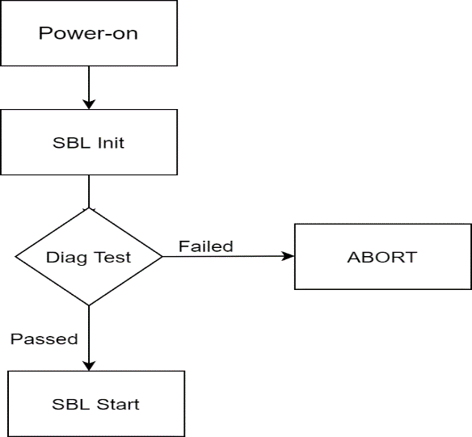

As soon as SBL is booted, it performs STC and PBIST on misc. device memory which may cause core reset. SBL uses SPARE register to store the test status during the test as SPARE register retains it value across soft/warm reset of the device which happens due to these destructive DIAG tests. After all these DIAG tests are pass, SBL moves to application loading flow where user can either opt to load new image over UART to sFlash (press space key) or load the existing image from sFlash (press ‘a’ to skip the counter).

### Diagnostic & Monitor Reference Application

Main application contains MSS and DSS core application where different set of diagnostic tests are executed. At the bootup it checks for boot status tests result and unhalts BSS & DSS core. In parallel to DSS diagnostic test execution, MSS runs set of R4F fault injection, self test, I/O and static diagnostic tests. Handshake of test status from DSS to MSS happens over HSRAM. Later to that MSS configures RadarSS for misc. monitoring features with a fixed set of configuration which user can change as required (rfmonitor_defaultCfg.c). All the monitoring APIs are configured to report only in case of failure. At every FTTI (monitor report interval), MSS application checks for any failure monitor report received by RadarSS in form of Async-event message and reports over UART. Along with this it executes set of static diagnostic tests as well periodically at every FTTI interval and reports this result also over UART. Refer MmwDemo_MonReportStreamTask function in diag_mon_main.c file.

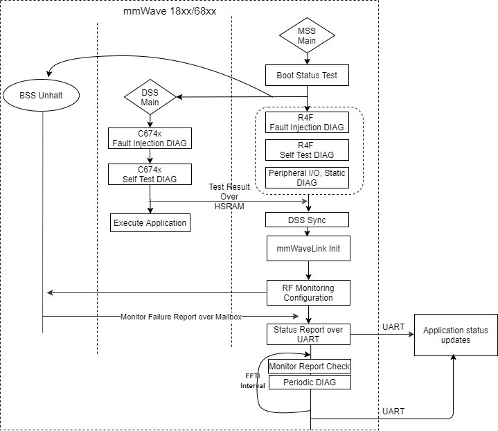

### OSAL Implementation

Diagnostic test from SDL uses OSAL to hook its ESM and CPU fault callbacks, so main application flow doesn’t get impacted. Most of diagnostic tests cause CPU or ESM fault, which may hamper main application flow. To avoid that Diagnostic Test attach a hook to OS or Non-OS (bare metal) layer for these CPU or ESM faults. These hooks get called as soon as Fault/Error caused by diagnostic test. Diagnostic test verifies its test flow based on its own hooks and returns the pass or fail of the test. Please refer mmwave_sdl_api.pdf from SDL installation path for more info. mmWave SDL provides OSAL implementation for Non-OS version whereas mmWave SDK provides OSAL for TI-RTOS. In this application OSAL is modified for NonOS and TI-RTOS according to the application requirements. Same OSAL is being used by the SBL as well. Refer source code at ‘ti\demo\diag_mon_ref\osal\src’ directory.

- MSS CPU Fault handler integration with TI-RTOS (sysBios) SysBios provides an exception hook where user application can attach its own function, so SysBios would invoke user-defined exception handler in lieu of SysBios Internal exception function. It is defined in mmw_mss.cfg file

```matlab
    /* to hook user-defined exception handlers */
    Exception.excHookFunc = '&MMW_EXCEPTION_HANDLER';
```

This exception handler is defined in osal_r4f_interrupt.c file where each type exception handler is updated by diagnostic test, so it can check the test status. Note: Since TI-RTOS aborts the application even if that exception is raised knowingly by the app (DIAG), so currently there is no way we can avoid application termination during this kind of DIAG test. Thus that specific DIAG (TCM 2-bit ECC) is not enabled in this application.

- MSS ESM Fault handler integration with TI-RTOS (sysBios) OSAL_R4F_ESMDrv_addHook function in OSAL (osal_r4f_esmdrv.c) is being used to register ESM fault handler with ESM driver of mmWave SDK. During the Diagnostic test, SDL add its own hook to ESM module to avoid any disturbance to main application.

# Need More Help?

- Find answers to common questions on [mmWave E2E FAQ](https://e2e.ti.com/support/sensor/mmwave_sensors/w/wiki)
- Search for your issue or post a new question on the [mmWave E2E forum](https://e2e.ti.com/support/sensor/mmwave_sensors/f/1023)